# IODS course project

### Multiple Correspondence Analysis

> Use Multiple Correspondence Analysis (MCA) on the tea data (or on just certain columns of the data, it is up to you!). Interpret the results of the MCA and draw at least the variable biplot of the analysis. You can also explore other plotting options for MCA. Comment on the output of the plots (0-4 points)

```r
library(FactoMineR)
mca <- tea %>% select(-age) %>% MCA
```

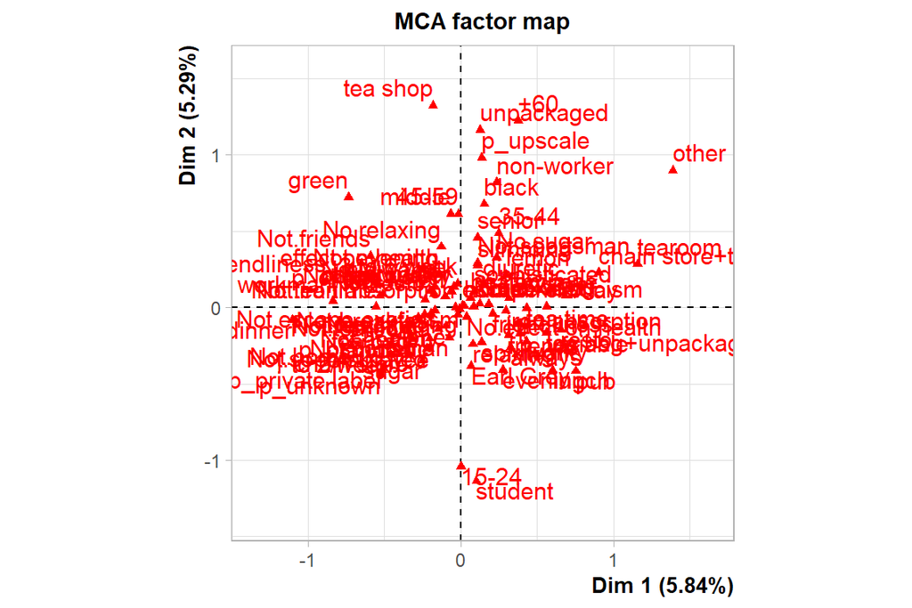

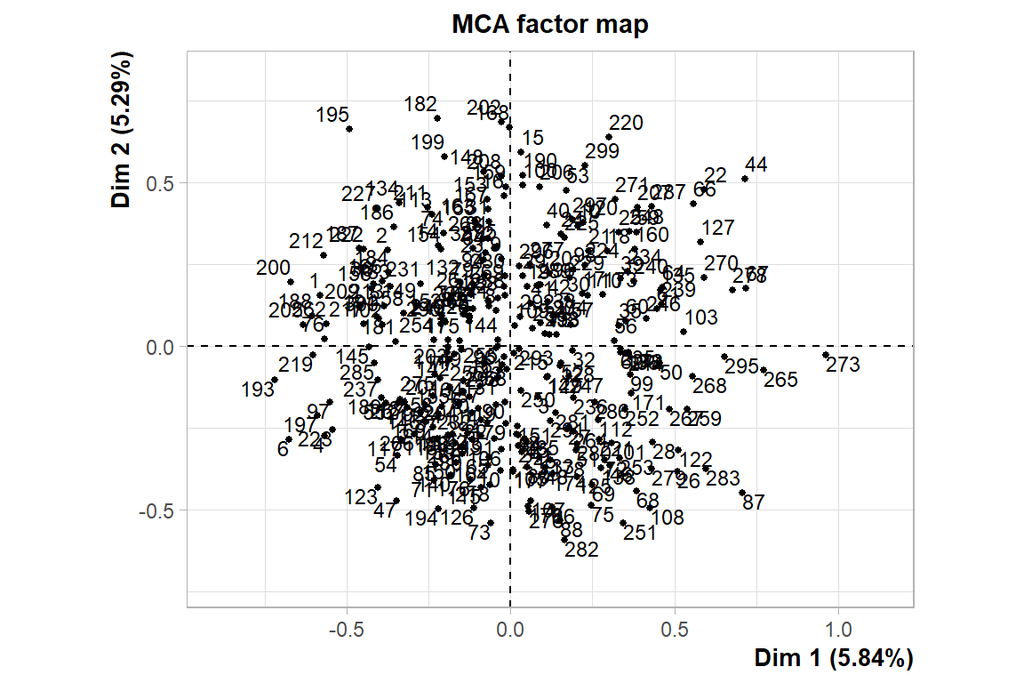

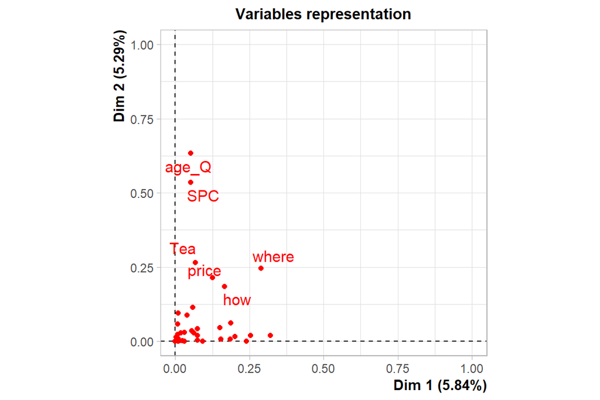

```r
summary(mca)
```

```
##
## Call:
## MCA(X = .)
##
##
## Eigenvalues
##                        Dim.1   Dim.2   Dim.3   Dim.4   Dim.5   Dim.6   Dim.7
## Variance               0.090   0.082   0.070   0.063   0.056   0.053   0.050
## % of var.              5.838   5.292   4.551   4.057   3.616   3.465   3.272
## Cumulative % of var.   5.838  11.130  15.681  19.738  23.354  26.819  30.091
##                        Dim.8   Dim.9  Dim.10  Dim.11  Dim.12  Dim.13  Dim.14
## Variance               0.048   0.047   0.044   0.041   0.040   0.039   0.037
## % of var.              3.090   3.053   2.834   2.643   2.623   2.531   2.388
## Cumulative % of var.  33.181  36.234  39.068  41.711  44.334  46.865  49.252
##                       Dim.15  Dim.16  Dim.17  Dim.18  Dim.19  Dim.20  Dim.21
## Variance               0.036   0.035   0.034   0.032   0.031   0.031   0.030
## % of var.              2.302   2.275   2.172   2.085   2.013   2.011   1.915
## Cumulative % of var.  51.554  53.829  56.000  58.086  60.099  62.110  64.025
##                       Dim.22  Dim.23  Dim.24  Dim.25  Dim.26  Dim.27  Dim.28
## Variance               0.028   0.027   0.026   0.025   0.025   0.024   0.024
## % of var.              1.847   1.740   1.686   1.638   1.609   1.571   1.524
## Cumulative % of var.  65.872  67.611  69.297  70.935  72.544  74.115  75.639
##                       Dim.29  Dim.30  Dim.31  Dim.32  Dim.33  Dim.34  Dim.35
## Variance               0.023   0.022   0.021   0.020   0.020   0.019   0.019
## % of var.              1.459   1.425   1.378   1.322   1.281   1.241   1.222
## Cumulative % of var.  77.099  78.523  79.901  81.223  82.504  83.745  84.967
##                       Dim.36  Dim.37  Dim.38  Dim.39  Dim.40  Dim.41  Dim.42
## Variance               0.018   0.017   0.017   0.016   0.015   0.015   0.014
## % of var.              1.152   1.092   1.072   1.019   0.993   0.950   0.924
## Cumulative % of var.  86.119  87.211  88.283  89.301  90.294  91.244  92.169
##                       Dim.43  Dim.44  Dim.45  Dim.46  Dim.47  Dim.48  Dim.49
## Variance               0.014   0.013   0.012   0.011   0.011   0.010   0.010
## % of var.              0.891   0.833   0.792   0.729   0.716   0.666   0.660
## Cumulative % of var.  93.060  93.893  94.684  95.414  96.130  96.796  97.456
##                       Dim.50  Dim.51  Dim.52  Dim.53  Dim.54
## Variance               0.009   0.009   0.008   0.007   0.006
## % of var.              0.605   0.584   0.519   0.447   0.390
## Cumulative % of var.  98.060  98.644  99.163  99.610 100.000
##
## Individuals (the 10 first)
```

[output cut: 44 more lines]

```
## dinner         0.796  1.805  0.048  3.777 |
## Not.dinner    -0.060  0.136  0.048 -3.777 |
##
## Categorical variables (eta2)
##                 Dim.1 Dim.2 Dim.3
## breakfast     | 0.031 0.000 0.011 |
## tea.time      | 0.240 0.000 0.003 |
## evening       | 0.040 0.087 0.062 |
## lunch         | 0.062 0.029 0.010 |
## dinner        | 0.092 0.000 0.048 |
## always        | 0.056 0.035 0.007 |
## home          | 0.016 0.002 0.030 |
## work          | 0.075 0.020 0.022 |
## tearoom       | 0.321 0.019 0.031 |
## friends       | 0.186 0.061 0.030 |
```

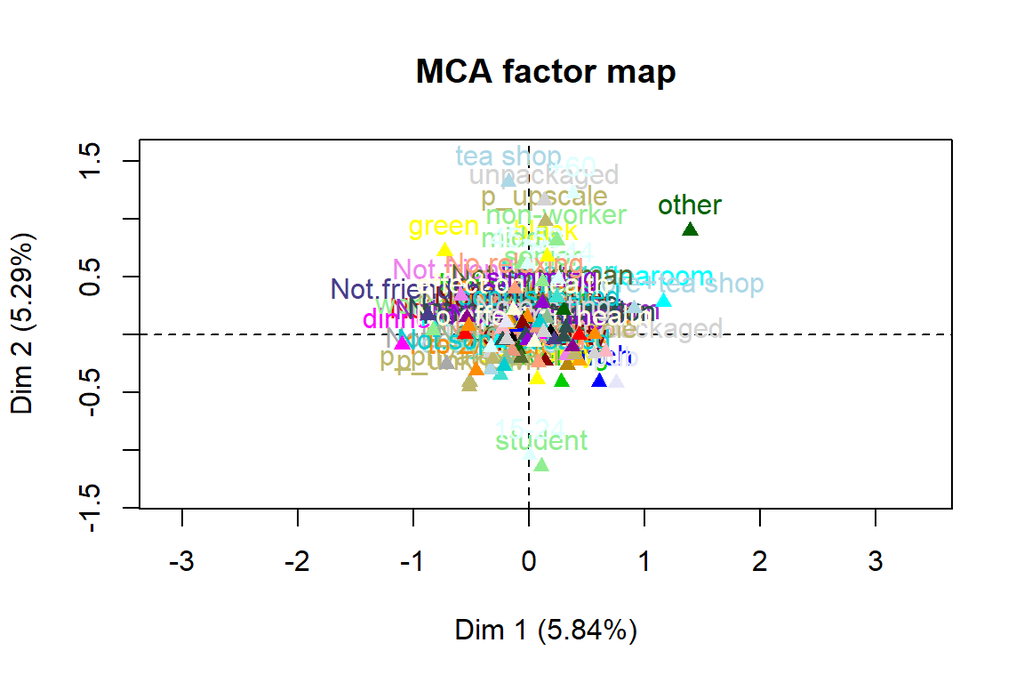

```r
mca %>% plot(
  invisible = c("ind"),
  habillage = "quali",
  graph.type = "classic"
)
```

# Analysis of Longitudinal Data

Loading the data

```r
library(tidyverse)
RatsL <- read_csv("data/RATSL.csv")
bprsL <- read_csv("data/BPRSL.csv")
RatsL %>% str
```

```
## spec_tbl_df [176 x 4] (S3: spec_tbl_df/tbl_df/tbl/data.frame)
##  $ ID    : num [1:176] 1 2 3 4 5 6 7 8 9 10 ...
##  $ Group : num [1:176] 1 1 1 1 1 1 1 1 2 2 ...
##  $ weight: num [1:176] 240 225 245 260 255 260 275 245 410 405 ...
##  $ Time  : num [1:176] 1 1 1 1 1 1 1 1 1 1 ...
##  - attr(*, "spec")=
##   .. cols(
##   ..   ID = col_double(),
##   ..   Group = col_double(),
##   ..   weight = col_double(),
##   ..   Time = col_double()
##   .. )
##  - attr(*, "problems")=<externalptr>
```

```r
bprsL %>% str
```

```
## spec_tbl_df [360 x 4] (S3: spec_tbl_df/tbl_df/tbl/data.frame)
##  $ treatment: num [1:360] 1 1 1 1 1 1 1 1 1 1 ...
##  $ subject  : num [1:360] 1 2 3 4 5 6 7 8 9 10 ...
##  $ bprs     : num [1:360] 42 58 54 55 72 48 71 30 41 57 ...
##  $ week     : num [1:360] 0 0 0 0 0 0 0 0 0 0 ...
##  - attr(*, "spec")=
##   .. cols(
##   ..   treatment = col_double(),
##   ..   subject = col_double(),
##   ..   bprs = col_double(),
##   ..   week = col_double()
##   .. )
##  - attr(*, "problems")=<externalptr>
```

```r
RatsL %>% summary
```

```
##        ID            Group          weight           Time
##  Min.   : 1.00   Min.   :1.00   Min.   :225.0   Min.   : 1.00
##  1st Qu.: 4.75   1st Qu.:1.00   1st Qu.:267.0   1st Qu.:15.00
##  Median : 8.50   Median :1.50   Median :344.5   Median :36.00
##  Mean   : 8.50   Mean   :1.75   Mean   :384.5   Mean   :33.55
##  3rd Qu.:12.25   3rd Qu.:2.25   3rd Qu.:511.2   3rd Qu.:50.00
##  Max.   :16.00   Max.   :3.00   Max.   :628.0   Max.   :64.00
```

```r
bprsL %>% summary
```

```
##    treatment      subject           bprs            week
##  Min.   :1.0   Min.   : 1.00   Min.   :18.00   Min.   :0
##  1st Qu.:1.0   1st Qu.: 5.75   1st Qu.:27.00   1st Qu.:2
##  Median :1.5   Median :10.50   Median :35.00   Median :4
##  Mean   :1.5   Mean   :10.50   Mean   :37.66   Mean   :4
##  3rd Qu.:2.0   3rd Qu.:15.25   3rd Qu.:43.00   3rd Qu.:6
##  Max.   :2.0   Max.   :20.00   Max.   :95.00   Max.   :8
```

There are two datasets for this week’s analysis. Both have been converted into long format, hence the *L* in their names. The *RatsL* data has 16 rats (ID) divided into 3 groups (Group) and the weight (weight) of each was measured several times during 64 days (Time).

In the *bprsL* dataset , short for brief psychiatric rating scale, a test score (bprs) was measured weekly (week) in 20 subjects (subject) per two treatment groups (treatment).

From the summaries we can see that the both datasets include quite a lot of variation.

Transforming categorical variables from numerical into factors:

```r
RatsL$ID <- factor(RatsL$ID)
RatsL$Group <- factor (RatsL$Group)

bprsL$treatment <- factor(bprsL$treatment)
bprsL$subject <- factor(bprsL$subject)

RatsL %>% str
```

```
## spec_tbl_df [176 x 4] (S3: spec_tbl_df/tbl_df/tbl/data.frame)
##  $ ID    : Factor w/ 16 levels "1","2","3","4",..: 1 2 3 4 5 6 7 8 9 10 ...
##  $ Group : Factor w/ 3 levels "1","2","3": 1 1 1 1 1 1 1 1 2 2 ...
##  $ weight: num [1:176] 240 225 245 260 255 260 275 245 410 405 ...
##  $ Time  : num [1:176] 1 1 1 1 1 1 1 1 1 1 ...
##  - attr(*, "spec")=
##   .. cols(
##   ..   ID = col_double(),
##   ..   Group = col_double(),
##   ..   weight = col_double(),
##   ..   Time = col_double()
##   .. )
##  - attr(*, "problems")=<externalptr>
```

```r
bprsL %>% str
```

```
## spec_tbl_df [360 x 4] (S3: spec_tbl_df/tbl_df/tbl/data.frame)
##  $ treatment: Factor w/ 2 levels "1","2": 1 1 1 1 1 1 1 1 1 1 ...
##  $ subject  : Factor w/ 20 levels "1","2","3","4",..: 1 2 3 4 5 6 7 8 9 10 ...
##  $ bprs     : num [1:360] 42 58 54 55 72 48 71 30 41 57 ...
##  $ week     : num [1:360] 0 0 0 0 0 0 0 0 0 0 ...
##  - attr(*, "spec")=
##   .. cols(
##   ..   treatment = col_double(),
##   ..   subject = col_double(),
##   ..   bprs = col_double(),
##   ..   week = col_double()
##   .. )
##  - attr(*, "problems")=<externalptr>
```

Great, now we can start diving in.

### RatsL

First, plotting RatsL data:

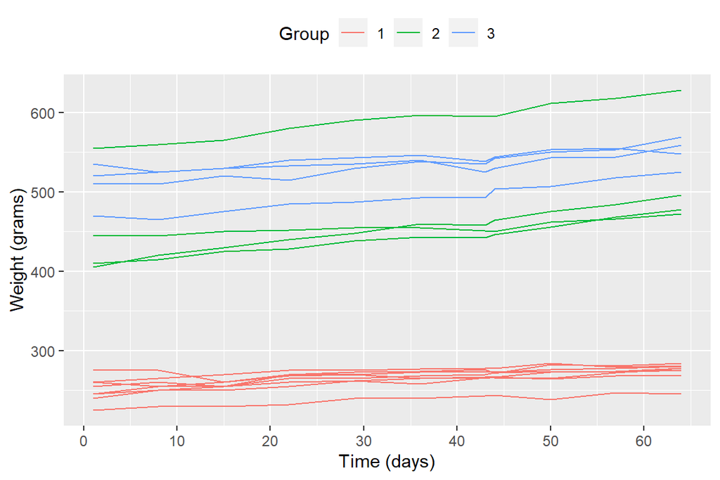

```r
library(ggplot2)
ggplot(RatsL, aes(x = Time, y = weight, group = ID)) +
  geom_line(aes(col = Group)) +
  theme(legend.position = "top") +
  scale_x_continuous(name = "Time (days)",
                     breaks = seq(0, 60, 10)) +
  scale_y_continuous(name = "Weight (grams)",
                     limits = c(min(RatsL$weight), max(RatsL$weight)))
```

There seems to be an increasing trend in weight in each group, but the groups have notably different starting weights. Group one seems to increase in weight less than groups 2 and 3.

Next, standardizing the data and plotting it:

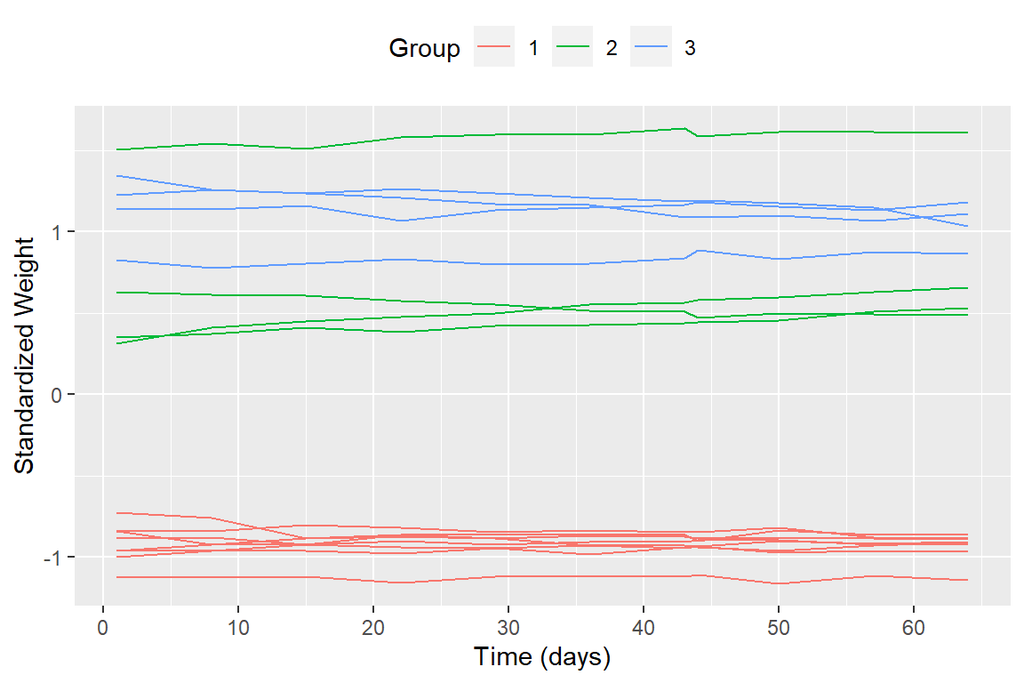

```r
RatsL <- RatsL %>%
  group_by(Time) %>%
  mutate(stdprs = scale(weight)) %>%
  ungroup

ggplot(RatsL, aes(x = Time, y = stdprs, group = ID)) +
  geom_line(aes(col = Group)) +
  theme(legend.position = "top") +
  scale_x_continuous(name = "Time (days)",
                     breaks = seq(0, 60, 10)) +
  scale_y_continuous(name = "Standardized Weight")
```

Honestly, I don’t know what this adds that we couldn’t see from the previous plot.

Moving on to a summary graph:

```r
n <- 16 # sample size

# creating a summary dataset
RatsLS <- RatsL %>%
  group_by(Group, Time) %>%
  summarise(mean = mean(weight), se = (sd(weight)/sqrt(n))) %>%
  ungroup
```

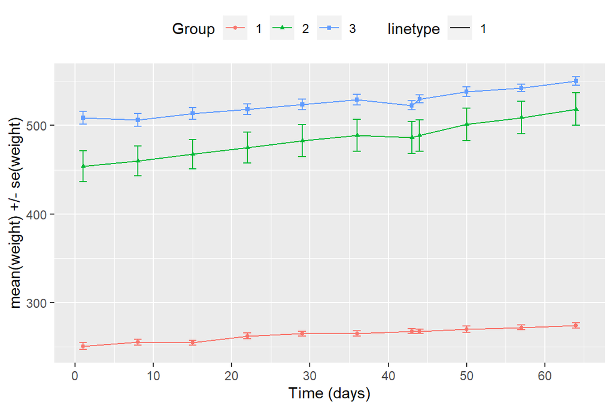

```r
# plotting the summary
RatsLS %>% ggplot(
  aes(x = Time, y = mean, shape = Group, col = Group)) +
  geom_line() +
  theme(legend.position = "top") +
  scale_x_continuous(name = "Time (days)",
                     breaks = seq(0, 60, 10)) +
   geom_errorbar(aes(ymin=mean-se, ymax=mean+se, linetype="1"), width=1) +
  geom_point(size = 1) +
  scale_y_continuous(name = "mean(weight) +/- se(weight)")
```

The summary graph shows us group averages and their standard errors instead of individuals. This makes the graph the easier to read the bigger the data.

Next, checking for outliers in the data using box plots:

```r
outlaw_rat <- RatsL %>%
  filter(Time > 1) %>% # removing baseline
  group_by(ID, Group) %>%
  summarise(mean = mean(weight)) %>%
  ungroup
```

[output not shown]

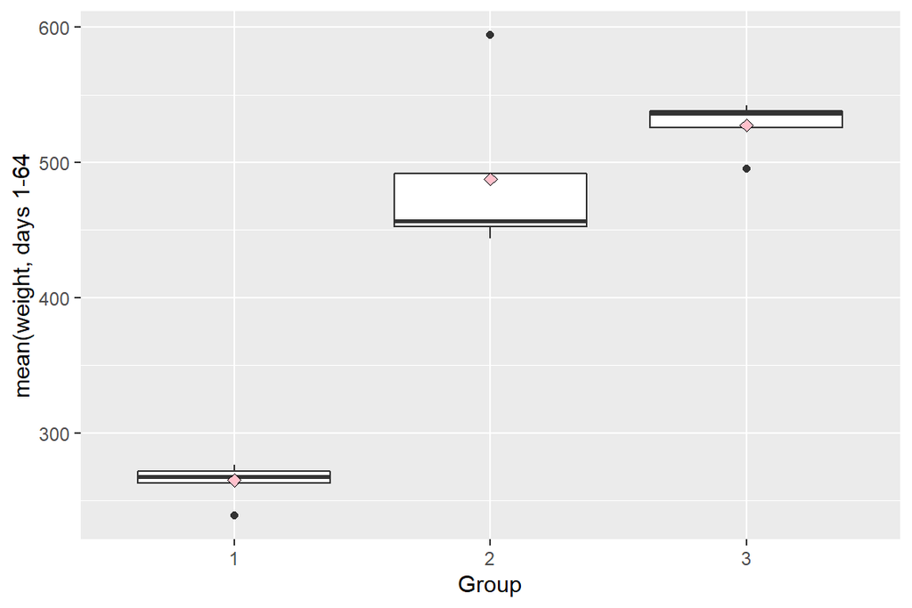

```r
outlaw_rat %>% ggplot(
  aes(x = Group, y = mean)) +
  geom_boxplot() +
  stat_summary(fun = "mean", geom = "point", shape = 23, size = 2, fill = "pink") +
  scale_y_continuous(name = "mean(weight, days 1-64")
```

Seems that each group has an outlier. I’m dubious of removing anything from such a small sample, but I’m gonna do it anyway for practice and replot.

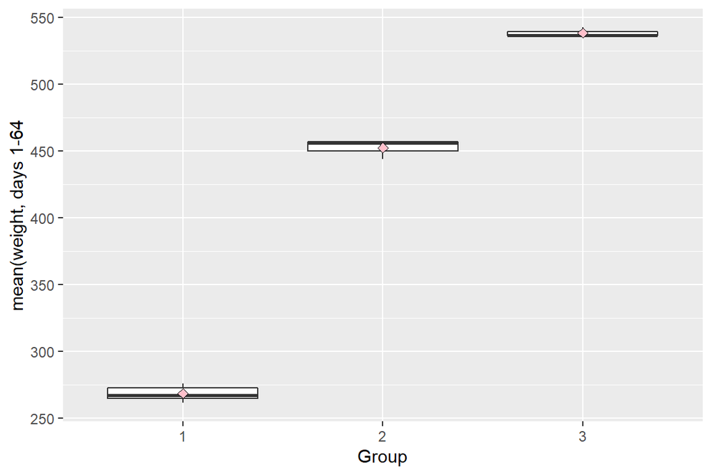

```r
outlaw_rat1 <- outlaw_rat %>% filter(mean > 240, # group 1 outlier
                                     mean < 550, # group 2 outlier
                                     mean > 500 | Group != 3)
                                                 # group 3 outlier
# plotting
outlaw_rat1 %>% ggplot(
  aes(x = Group, y = mean)) +
  geom_boxplot() +
  stat_summary(fun = "mean", geom = "point", shape = 23, size = 2, fill = "pink") +
  scale_y_continuous(name = "mean(weight, days 1-64")
```

Yay, done. Now, it’s obvious enough just from the graphs that these groups of rats have very different weight, but let’s test that quantitatively anyway for the fun of it. Performing a pairwise t-test:

```r
library(rstatix)
outlaw_rat1 %>%
  pairwise_t_test(mean ~ Group, p.adjust.method = "bonferroni")
```

```
## # A tibble: 3 x 9
##   .y.   group1 group2    n1    n2        p p.signif    p.adj p.adj.signif
## * <chr> <chr>  <chr>  <int> <int>    <dbl> <chr>       <dbl> <chr>
## 1 mean  1      2          7     3 3.99e-13 ****     1.2 e-12 ****
## 2 mean  1      3          7     3 8.71e-15 ****     2.61e-14 ****
## 3 mean  2      3          3     3 3.86e- 9 ****     1.16e- 8 ****
```

As the test shows, the groups have different weight at amusingly low p-values.

Finally, calculating a linear model for the data:

```r
# loading the starting weight of the rats
baseline <- RatsL %>% filter(Time==1) %>% select(weight) %>% as.vector

# adding the baseline weight as a column to a data frame
outlaw_rat2 <- outlaw_rat %>%
  mutate(baseline = baseline$weight)

# calculating a linear model for the data
rat_fit <- lm(mean ~ baseline + Group, data = outlaw_rat2)

rat_fit %>% anova
```

```
## Analysis of Variance Table
##
## Response: mean
##           Df Sum Sq Mean Sq   F value   Pr(>F)
## baseline   1 253625  253625 1859.8201 1.57e-14 ***
## Group      2    879     439    3.2219  0.07586 .
## Residuals 12   1636     136
## ---
## Signif. codes:  0 '***' 0.001 '**' 0.01 '*' 0.05 '.' 0.1 ' ' 1
```

The ANOVA table shows us that the baseline weight is strongly related to the later weight measurements, whereas with a p-value of about 0.076 we cannot be very confident in saying that the groups had a difference in weight gain.